# Introduction of the 3PG model

By：Juergen Knauer (J.Knauer@westernsydney.edu.au). Original material from: Jinyan Yang Email: jyyoung@live.com

2023-08-13

## 1.Introduction

The model “Physiological Processes Predicting Growth”（3PG） model was first published by [Landsberg and Waring (1997)] https://www.sciencedirect.com/science/article/pii/S0378112797000261).

The goal of 3PG is to predict forest productivity and evapotranspiration based on physiological processes. The core assumption is gross primary production (GPP) can be calculated from solar irradiance and light use efficiency, while light use efficiency depends on temperature, humidity, soil moisture, soil nutrient, tree age and atmospheric carbon dioxide concentration (Ca).

The key features of the 3PG are: 1. detailed physiological processes; 2. realistic climate change responses; 3. dynamics species composition; 4. Easy to use considering its capability.

3PG runs on a monthly time step with an undefined spatial resolution. The minimum climate inputs to the model are solar radiation, precipitation, temperature and atmospheric humidity. There are 82 physiological parameters and 54 parameters describing the initial state.

Given the advantages of 3PG, it has been widely adapted around the world and is one of the most common model used in forestry. There are now over 100 studies that have used 3PG.

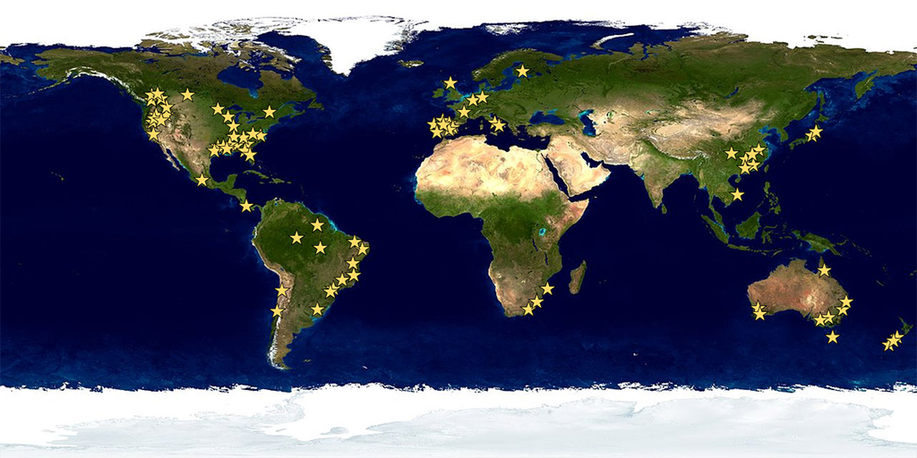

Fig 1. Studies sites used 3PG.

There are a number of useful materials online: https://3pg.forestry.ubc.ca/

The version that we are using today is： https://doi.org/10.1111/2041-210X.13474

## 2. Model structure

3PG has a structure that is typical for most land surface models. The basic assumption is that plants turn solar radiation into carbon, which is then used to grow roots, stem and foliage.

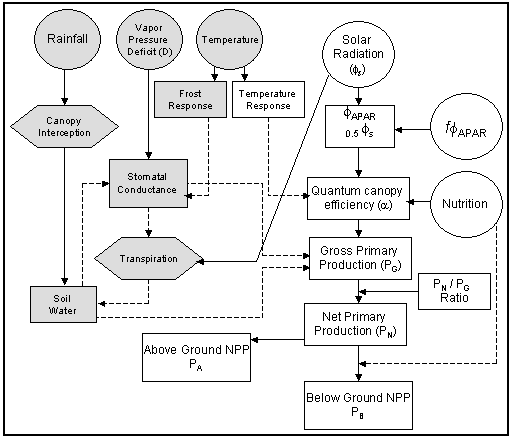

Fig 2. Flow chart of key processes in 3PG.

## 3.Programing language

We use the R languagehttps://www.r-project.org/ and RStudio IDE https://www.rstudio.com/. The details of how to install and use the software are available through the links.

Briefly, R is a programming language designed for statistics but now adapted many features which makes it as capable as any other language. It is the most commonly used language in scientific research.

The package we will use today is ‘r3PG’.

```r
# Install the package
if(require('r3PG') == FALSE){
  install.packages('r3PG')
}

#
library('r3PG')
```

## 4.Getting familiar with the code

### 4.1 Find help

The most important thing to deal with unknown information in R–and in any programming language, is to find help page.

```r
help(package = r3PG)
```

List the content.

```r
ls("package:r3PG")
```

```
##  [1] "d_climate"          "d_parameters"       "d_site"
##  [4] "d_sizeDist"         "d_species"          "d_thinning"
##  [7] "get_parameters"     "i_output"           "i_parameters"
## [10] "i_parameters_lit"   "i_sizeDist"         "prepare_climate"
## [13] "prepare_input"      "prepare_parameters" "prepare_site"
## [16] "prepare_sizeDist"   "prepare_species"    "prepare_thinning"
## [19] "run_3PG"
```

### 4.2 Explore data structure

Two basic commands are useful here: ‘str’ returns the structure of the object.

```r
str(d_climate)
```

```
## Classes 'tbl_df', 'tbl' and 'data.frame':    168 obs. of  10 variables:
##  $ year      : num  2001 2001 2001 2001 2001 ...
##  $ month     : num  1 2 3 4 5 6 7 8 9 10 ...
##  $ tmp_min   : num  -1.467 -0.862 3.805 2.795 9.755 ...
##  $ tmp_max   : num  4.43 7.55 11.46 11.35 20.88 ...
##  $ tmp_ave   : num  1.26 2.98 7.34 6.59 15.16 ...
##  $ prcp      : num  107 29 195.8 144 57.2 ...
##  $ srad      : num  8.41 12.66 15.91 17.78 21.5 ...
##  $ frost_days: num  19 14 14 6 0 0 0 0 0 0 ...
##  $ co2       : num  360 360 360 360 360 ...
##  $ d13catm   : num  -7.68 -7.68 -7.68 -7.68 -7.68 ...
```

We can use ‘head’ to see the initial rows of a data set (called ‘data frame’ in R). Other useful commands are ‘tail’ and ‘summary’.

```r
head(d_climate)
```

```
##   year month    tmp_min   tmp_max   tmp_ave      prcp      srad frost_days
## 1 2001     1 -1.4669526  4.426295  1.255187 107.00000  8.406893         19
## 2 2001     2 -0.8616548  7.553571  2.982143  29.00000 12.664019         14
## 3 2001     3  3.8046124 11.463667  7.340946 195.79700 15.905757         14
## 4 2001     4  2.7947164 11.352311  6.585644 144.00001 17.775332          6
## 5 2001     5  9.7551870 20.884220 15.156178  57.20299 21.501787          0
## 6 2001     6 10.0666666 21.166666 15.428050 241.11404 18.191631          0
##       co2   d13catm
## 1 360.000 -7.677826
## 2 360.036 -7.677826
## 3 360.072 -7.677826
## 4 360.108 -7.677826
## 5 360.144 -7.677826
## 6 360.180 -7.677826
```

```r
head(i_parameters)
```

```
##   parameter                                     description unit default
## 1      pFS2        Foliage:stem partitioning ratio @ D=2 cm    -   1.000
## 2     pFS20       Foliage:stem partitioning ratio @ D=20 cm    -   0.150
## 3       aWS Constant in the stem mass v. diam. relationship    -   0.095
## 4       nWS    Power in the stem mass v. diam. relationship    -   2.400
## 5       pRx                Maximum fraction of NPP to roots    -   0.800
## 6       pRn                Minimum fraction of NPP to roots    -   0.250
```

### 4.3 Look into a function

Here we use ‘prepare_input’ function as an example.

```r
?prepare_input
```

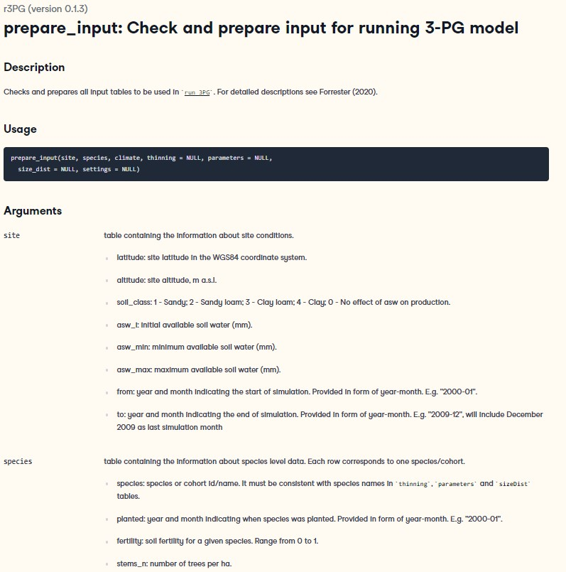

Help page of the function

### 4.5 Run the model

Now we can already run the model! We do that by running the run_3PG command, the output of which is stored into an object called ‘output’.

```r
output <- run_3PG(site = d_site,              # site related initial settings
                  species = d_species,        # species information
                  climate = d_climate,        # climate
                  thinning = NULL,            # thinning (not considered here)
                  parameters = d_parameters,  # parameter values by species
                  size_dist = d_sizeDist,     # allometry
                  settings = list(light_model = 1,
                                  transp_model = 2, phys_model = 2,
                                  correct_bias = 0, calculate_d13c = 0),
                  check_input = TRUE, df_out = TRUE)


head(output)
```

```
##         date         species   group variable      value
## 1 2001-01-31 Fagus sylvatica climate  tmp_min -1.4669526
## 2 2001-02-28 Fagus sylvatica climate  tmp_min -0.8616548
## 3 2001-03-31 Fagus sylvatica climate  tmp_min  3.8046124
## 4 2001-04-30 Fagus sylvatica climate  tmp_min  2.7947164
## 5 2001-05-31 Fagus sylvatica climate  tmp_min  9.7551870
## 6 2001-06-30 Fagus sylvatica climate  tmp_min 10.0666666
```

Let’s look at the output

```r
str(output)
```

```
## 'data.frame':    36000 obs. of  5 variables:
##  $ date    : Date, format: "2001-01-31" "2001-02-28" ...
##  $ species : chr  "Fagus sylvatica" "Fagus sylvatica" "Fagus sylvatica" "Fagus sylvatica" ...
##  $ group   : chr  "climate" "climate" "climate" "climate" ...
##  $ variable: chr  "tmp_min" "tmp_min" "tmp_min" "tmp_min" ...
##  $ value   : num  -1.467 -0.862 3.805 2.795 9.755 ...
```

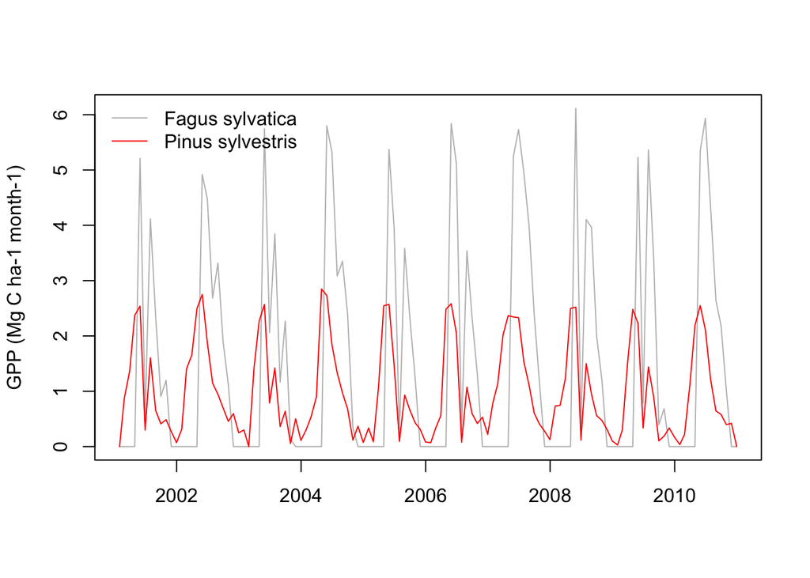

```r
plot(value~date,data = output[output$species == 'Fagus sylvatica' &
                                output$variable == 'gpp',],
     type='l',xlab='',ylab='GPP (Mg C ha-1 month-1)',col='grey')

points(value~date,data = output[output$species == 'Pinus sylvestris' &
                                output$variable == 'gpp',],
     type='l',xlab='',ylab='GPP (Mg C ha-1 month-1)',col='red')

legend('topleft',legend = unique(output$species),
       lty='solid',col=c('grey','red'),bty='n')
```

## 5 Input and output

I summarised the input and output data format, variable name and units. There is no need for you to memorise this, but keep in mind this information can be found here.

Let’s have a look at what the inputs and outputs of the models are.

### Table 1. Parameters used in 3PG.

| parameter | description | unit | default |
| --- | --- | --- | --- |
| pFS2 | Foliage:stem partitioning ratio @ D=2 cm | - | 1.000 |
| pFS20 | Foliage:stem partitioning ratio @ D=20 cm | - | 0.150 |
| aWS | Constant in the stem mass v. diam. relationship | - | 0.095 |
| nWS | Power in the stem mass v. diam. relationship | - | 2.400 |
| pRx | Maximum fraction of NPP to roots | - | 0.800 |
| pRn | Minimum fraction of NPP to roots | - | 0.250 |
| gammaF1 | Maximum litterfall rate | 1/month | 0.027 |
| gammaF0 | Litterfall rate at t = 0 | 1/month | 0.001 |
| tgammaF | Age at which litterfall rate has median value | months | 12.000 |
| gammaR | Average monthly root turnover rate | 1/month | 0.015 |
| leafgrow | If deciduous, leaves are produced at end of this month | month | 0.000 |
| leaffall | If deciduous, leaves all fall at start of this month | month | 0.000 |
| Tmin | Minimum temperature for growth | deg. C | 8.500 |
| Topt | Optimum temperature for growth | deg. C | 16.000 |
| Tmax | Maximum temperature for growth | deg. C | 40.000 |
| kF | Days production lost per frost day | days | 0.000 |
| SWconst | Moisture ratio deficit for fq = 0.5 | - | 0.700 |
| SWpower | Power of moisture ratio deficit | - | 9.000 |
| fCalpha700 | Assimilation enhancement factor at 700 ppm | - | 1.400 |
| fCg700 | Canopy conductance enhancement factor at 700 ppm | - | 0.700 |
| m0 | Value of ‘m’ when FR = 0 | - | 0.000 |
| fN0 | Value of ‘fNutr’ when FR = 0 | - | 1.000 |
| fNn | Power of (1-FR) in ‘fNutr’ | - | 0.000 |
| MaxAge | Maximum stand age used in age modifier | years | 50.000 |
| nAge | Power of relative age in function for fAge | - | 4.000 |
| rAge | Relative age to give fAge = 0.5 | - | 0.950 |
| gammaN1 | Mortality rate for large t | %/year | 0.000 |
| gammaN0 | Seedling mortality rate (t = 0) | %/year | 0.000 |
| tgammaN | Age at which mortality rate has median value | years | 0.000 |
| ngammaN | Shape of mortality response | - | 1.000 |

[output cut: 52 more lines]

### Table 2. Meterological inputs.

| Variable | Description | Unit |
| --- | --- | --- |
| year | year | - |
| month | month | - |
| tmp_min | monthly mean daily minimum temperature | Celsius |
| tmp_max | monthly mean daily maximum temperature | Celsius |
| prcp | monthly rainfall | mm month-1 |
| srad | monthly mean daily solar radiation | MJ m-2 d-1 |
| frost_days | frost days per month | day |
| co2 | monthly mean atmospheric co2 | p.p.m |

### Table 3. Site specific inputs and initial conditions.

[output not shown]

### Table 4. Species specific inputs and initial biomass.

| Variable | Description | Unit |
| --- | --- | --- |
| species |  | - |
| planted | year and month indicating when species was planted | - |
| fertility | soil fertility for a given species | 0-1 |
| stems_n | number of trees per ha | No./ha |
| biom_stem | stem biomass for a given species | Mg/ha |
| biom_root | root biomass for a given species | Mg/ha |
| biom_foliage | initial foliage biomass | Mg/ha |

### Table 5. Thinning parameters.

| Variable | Description |
| --- | --- |
| species |  |
| age | age when thinning is performed |
| stems_n | number of trees per ha after thinning |
| stem | type of thinning (above/below) |
| root | type of thinning (above/below) |
| foliage | type of thinning (above/below) |

### Table 6. Output format.

| group_id | variable_id | variable_name | variable_group | description | unit | variable_vba |
| --- | --- | --- | --- | --- | --- | --- |
| 1 | 1 | tmp_min | climate | Minimum daily temperature | C | Min temp. |
| 1 | 2 | tmp_max | climate | Maximum daily temperature | C | Max temp. |
| 1 | 3 | tmp_ave | climate | Mean daily temperature | C | Mean temp. |
| 1 | 4 | frost_days | climate | Number of frost days per month | d month-1 | Frost days |
| 1 | 5 | solar_rad | climate | Mean daily incident solar radiation | MJ m-2 d-1 | Solar rad. |
| 1 | 6 | day_length | climate | Day length (sunrise to sunset) | s d-1 | Daylength |
| 1 | 7 | prcp | climate | Monthly precipitation sum | mm month-1 | Rainfall |
| 1 | 8 | vpd_day | climate | Mean day-time VPD | mbar | VPD |
| 1 | 9 | co2 | climate | Atmospheric CO2 | ppm | CO2 |
| 1 | 10 | delta13c | climate | Delta 13C of the atmosphere | NA | atm delta 13C |
| 1 | 11 | var_1_11 | climate | Applied irrigation | mm month-1 | Applied irrig. |
| 1 | 12 | var_1_12 | climate | NA | NA | NA |
| 1 | 13 | var_1_13 | climate | NA | NA | NA |
| 1 | 14 | var_1_14 | climate | NA | NA | NA |
| 1 | 15 | var_1_15 | climate | NA | NA | NA |
| 2 | 1 | age | stand | Species age | years | Age species |
| 2 | 2 | stems_n | stand | Stand stocking | trees ha-1 | Stems |
| 2 | 3 | basal_area | stand | Stand basal area | m2 ha-1 | Basal area |
| 2 | 4 | basal_area_prop | stand | Proportion of stand basal area (totalBA) contributed by the given species species | % | SpeciesProportionBA |
| 2 | 5 | dbh | stand | Mean DBH | cm | Mean DBH |
| 2 | 6 | height | stand | Mean height | m | Height |
| 2 | 7 | height_rel | stand | Height of the given species divided by the mean height of all trees in the stand (e.g. mean height of all species weighted by the number of trees per ha of that species) | - | SpeciesProportionLAI |
| 2 | 8 | crown_length | stand | Mean live-crown length | m | LCL |
| 2 | 9 | crown_width | stand | Mean crown diameter | m | crowndiameter |
| 2 | 10 | volume | stand | Stand volume excluding branch & bark | m3 ha-1 | Stand volume |
| 2 | 11 | volume_mai | stand | Mean annual volume increment | m3 ha-1 yr-1 | MAI |
| 2 | 12 | volume_change | stand | Stem volume increment in current period | m3 ha-1 | CVI |
| 2 | 13 | volume_cum | stand | Total cumulative volume (stand volume + extracted volume + mortality) | m3 ha-1 | Total cumulative volume |
| 2 | 14 | var_2_14 | stand | NA | NA | NA |
| 2 | 15 | var_2_15 | stand | NA | NA | NA |

[output cut: 120 more lines]

## 6. Physiological processes - Productivity

### 6.1 Gross Primary Productivity

In 3PG, Gross Primary Productivity (GPP) is a function of light, light use efficiency, and environmental modifiers.

$$GPP = Qf_l(L) \alpha f_t(T)f_w(W)f_g(g_s)~~~~~~~~(1)$$

### 6.2 Light

3PG uses monthly mean daily solar radiation in unit of $MJ~m^{-2}~d^{-1}$. Note that the raw radiation measurements come in various formats and need to be converted to the correct unit.

### 6.3 Leaf area index

The amount of light absorbed by plants is a function of leaf area index (L) based on Beer–Lambert Law:
$$f_l =
(1-e^{-kL})~~~~~~~~(2)$$
Here k is light extinction coefficient usually taken as 0.5.

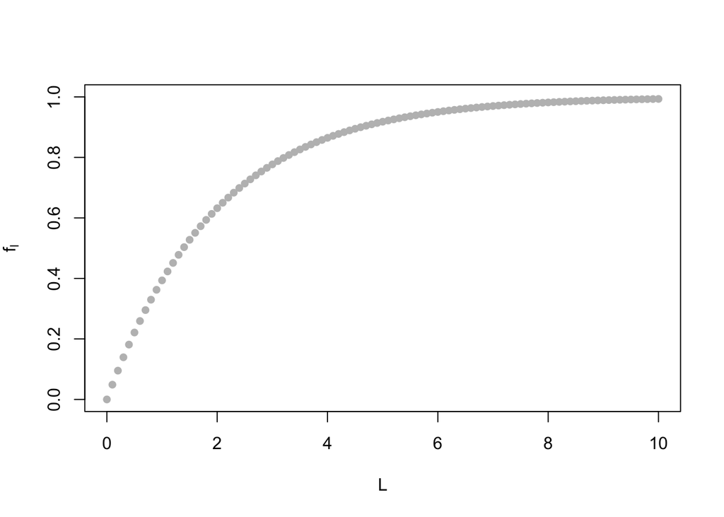

```r
# make a vector of LAI
lai.vec <- seq(0,10,by=0.1)
# calculate light absorption
plot.df <- data.frame(lai = lai.vec,
                      f.low = 1-exp(-0.5*lai.vec))
# plot LAI and light absorption
plot(f.low~lai,data = plot.df,
     type='p',pch=16,xlab='L',ylab=expression(f[l]),col='grey',
     ylim=c(0,1))
```

This relationship depends on L only. L is product of leaf biomass and specific leaf area (SLA). As a result, the value of SLA is particularly important for correct L and light absorption.

$Qf_l(L)$ is also known as fAPAR - the fraction of absorbed photosynthetically active radiation, which is a central property in land surface and climate models.

### 6.4 Light use efficiency

Light use efficiency（$\alpha$）is the unit carbon produced from one unit absorbed light（$g~MJ^{-1}$）。$\alpha$ describes the slope of GPP over absorbed radiation.

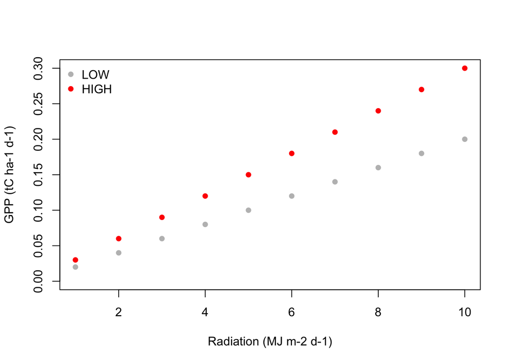

```r
# Light use efficiency
Q <- 1:10
alpha.low  <- 0.02
alpha.high <- 0.03
plot.df <- data.frame(Q,
                      GPP.low = Q * alpha.low,
                      GPP.high = Q * alpha.high)

plot(GPP.low~Q,data = plot.df,
     type='p',pch=16,xlab='Radiation (MJ m-2 d-1)',ylab='GPP (tC ha-1 d-1)',col='grey',
     ylim=c(0,0.3))

points(GPP.high~Q,data = plot.df,
     type='p',pch=16,xlab='',col='red')

legend('topleft',legend = c('LOW','HIGH'),
       pch=16,col=c('grey','red'),bty='n')
```

Above is the most important assumptions in 3PG, with which we can calculate GPP already.

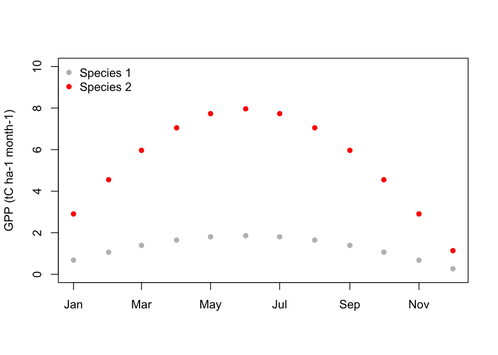

```r
# parameter values
par.dummy.df <- data.frame(species = c('species1','species2'),
                      lai = c(0.5,2),
                      alpha = c(alpha.low,alpha.high))
# light
met.dummy.df <- data.frame(date = seq(as.Date('2000-1-1'),
                                      as.Date('2000-12-31'),by='month'),
                           solar = 12*sin((1:12)/12*pi) + 2)
# day to month conversion
dayInMonth = 30

# GPP
met.dummy.df$gpp.x1 <- par.dummy.df$alpha[par.dummy.df$species=='species1']*
  (1-exp(-0.5*par.dummy.df$lai[par.dummy.df$species=='species1'])) *
  met.dummy.df$solar * dayInMonth

met.dummy.df$gpp.x2 <- par.dummy.df$alpha[par.dummy.df$species=='species2']*
  (1-exp(-0.5*par.dummy.df$lai[par.dummy.df$species=='species2']))*
  met.dummy.df$solar * dayInMonth

# make plot
plot(gpp.x1 ~ date,data = met.dummy.df,
     type='p',pch=16,xlab=' ',ylab='GPP (tC ha-1 month-1)',col='grey',
     ylim=c(0,10))
points(gpp.x2 ~ date,data = met.dummy.df,
     type='p',pch=16,ylab=expression(f[l]),col='red')

legend('topleft',legend = c('Species 1','Species 2'),
       pch=16,col=c('grey','red'),bty='n')
```

### 6.5 Temperature

In 3PG, temperature gains impact via:
$$f_t = \frac{T_{mean} - T_{min}} {T_{opt} -
T_{min}} (\frac{T_{max} - T_{mean}} {T_{max} - T_{opt}})^{\frac{T_{max}
- T_{opt}}{T_{opt} - T_{min}}}~~~~~~~~(3)$$
This equation is a widely used empirical function. It assumes the impact of temperature being smaller when closer to the optimal temperature（$T_{opt}$).

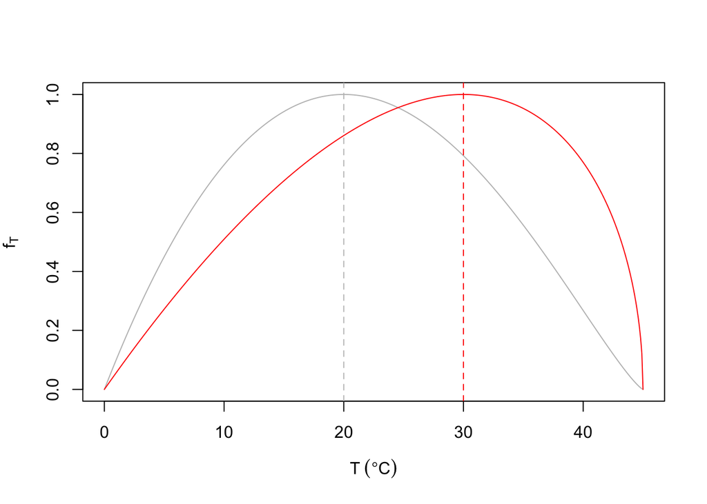

```r
# temperature
tmin= 0
tmax=45
t.vec <- seq(tmin,tmax,by=0.1)

# calculate T effect
t.func <- function(t.vec,t.opt,t.max,t.min){
  ((t.vec - t.min) / (t.opt - t.min)) *
    ((t.max - t.vec) / (t.max - t.opt))^((t.max - t.opt)/(t.opt - t.min))
}

ft20 <- t.func(t.vec,t.opt = 20,t.max = tmax,t.min = tmin)
ft30 <- t.func(t.vec,t.opt = 30,t.max = tmax,t.min = tmin)
# make plot
plot(ft20~t.vec,
     type='l',xlab=expression(T~(degree*C)),
     ylab=expression(f[T]),col='grey',
     ylim=c(0,1))

points(ft30~t.vec,
     type='l',pch=16,xlab='',col='red')
abline(v=20,col='grey',lty='dashed')
abline(v=30,col='red',lty='dashed')
```

### 6.6 Soil moisture

The impact of dry soil on productivity is based on Landsberg and Waring (1997) which is soil type specific.

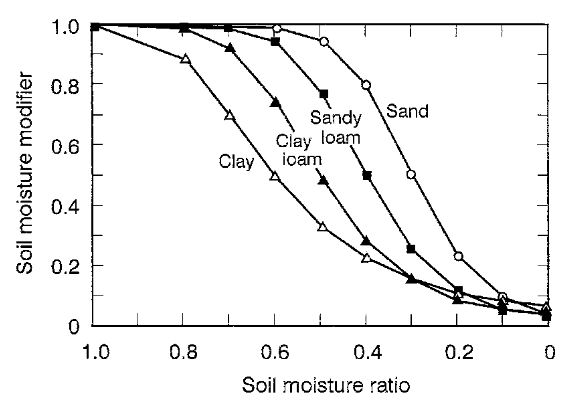

What else does the soil moisture modifier depend on?

### 6.7 Stomatal Conductance

where $g_{s.max}$ and $k_{g}$are species specific parameters。$k_{g}=0.05$ is a common assumption。

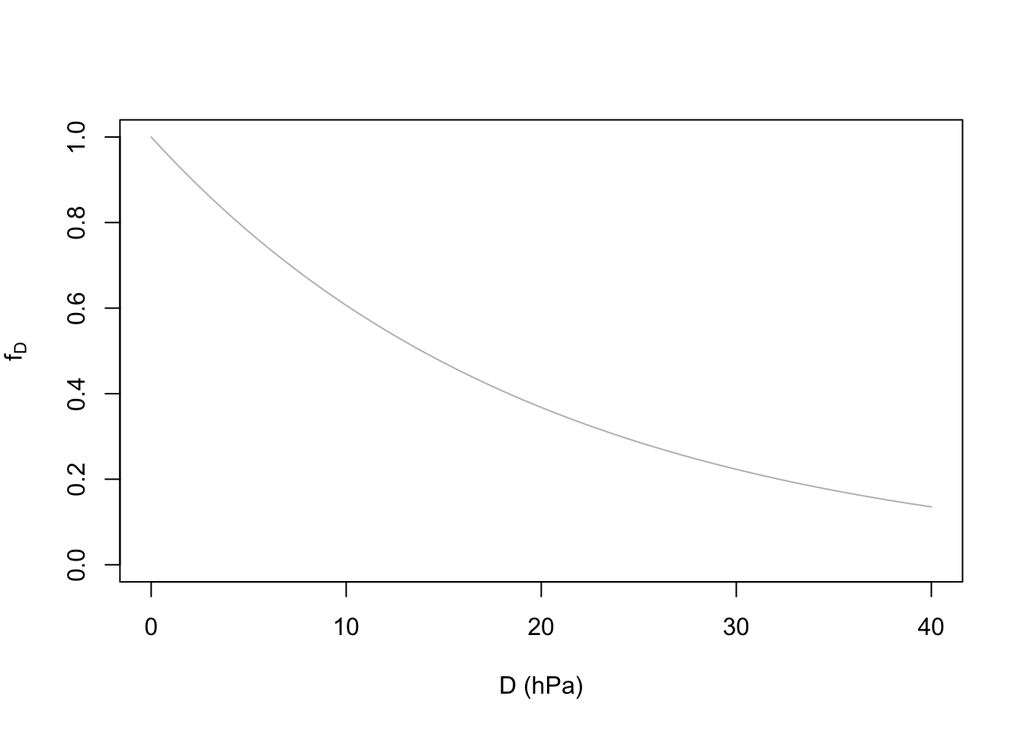

```r
# VPD
gmax1= 0.1
vpd.vec <- seq(0,40,by=0.1)

# VPD effect
vpd.func <- function(vpd,gmax,k = 0.05){
  exp(-k*vpd)
}

f.g.1 <- vpd.func(vpd.vec,gmax = gmax1)
# make plot
plot(f.g.1~vpd.vec,
     type='l',xlab=('D (hPa)'),
     ylab=expression(f[D]),col='grey',
     ylim=c(0,1))
```

### 6.8 Frost, age and soil nutrients

In 3PG, the days that have frost do not have GPP.

Age affects GPP through a decrease in maximum stomatal conductance when the forest ages.

It worth noting that soil nutrients are not modelled in 3PG. However, nutrient availability affects carbon allocation to different plant components (roots, leaves, stems) in the model.

### 6.9 CO2 response

The CO2 response curve is based on:

$$f_{c}=\frac{f_{Calpha700}}
{(2-f_{Calpha700})} ~~~~~~~~(5)$$

It has a direct impact on light use efficiency：

$$f_{alpha,CO_{2}}=\frac{f_{c} CO_{2}}
{(350(f_{c}-1)+CO_{2}} ~~~~~~~~(6)$$

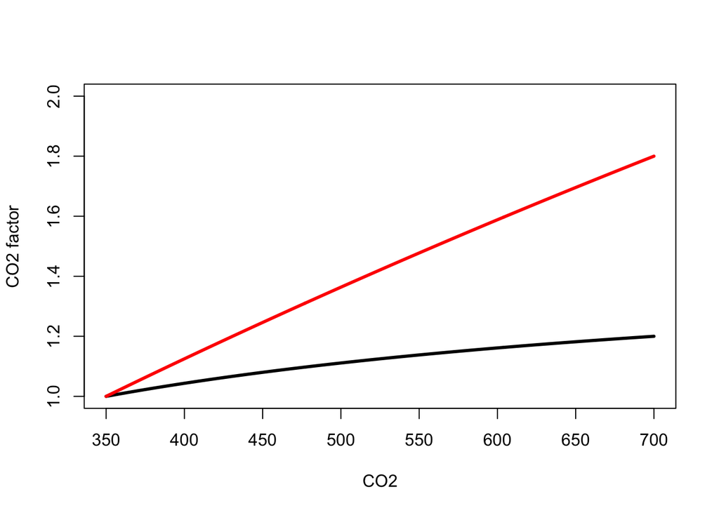

```r
plot.co2.response.func <- function(fc.700 = 1.8,add.plot=FALSE){
  co2 <- seq(350,700)
fC = fc.700 / (2 - fc.700)
falpha = fC * co2 / (350* (fC - 1) + co2)
if(add.plot){
  points(falpha~co2,type='l',col='red',lwd=3)
}else{
  plot(falpha~co2,xlab='CO2',ylab='CO2 factor',type='l',ylim=c(1,2),lwd=3)
}

}
plot.co2.response.func(fc.700 = 1.2)
plot.co2.response.func(fc.700 = 1.8,add.plot = T)
```

## 7.Physiological processes - water cycle

### 7.1 From precipitation to transpiration

Precipitation will first be intercepted by the canopy. The through-fall will be evenly distributed throughout the soil. There are two ways for water to come out of soil-transpiration and evaporation. Both of the processes are calculated with the Penman-Monteith equation.

$$E= \frac{g_{c}}{\lambda} \frac{e_{20}
R_{net} + \rho_{air} \lambda / r_{aero} }{g_{c}(1+e_{20}) + 1/r_{aero}}
d_{length}~~~~~~~~(5)$$
where E is the transpiration ($kg~m^{-2}h^{-1}$). $g_{c}$ is canopy conductance ($m~s^{-1}$). When calculating soil evaporation then $g_{c}$ should be replaced with soil conductance. $\lambda$ is latent heat of vaporisation (2460000$J~kg^{-1}$). $e_{20}$ is the slope of D against temperature (2.2$kPa~ ^\circ C^{-1}$). $R_{net}$ is net radiation ($MJ~m^{-2}~h^{-1}$). In the model, $R_{net}$ is calculated as solar radiation times $f_l$. $\rho_{air}$ is the air density (1.2$kg~m^{-3}$). $r_{aero} $is aerodynamic resistance($m~s^{-1}$). $d_{length}$ is the number of hours in a day.

For multi-species simulation, the transpiration is calculated separately with L for each species. The sum of transpiration and evaporation is called evapotranspiration (ET), the total mass flux of water from the surface to the atmosphere. ET can be converted to its energy equivalent, the latent heat flux using $\lambda$. When we know $\lambda E$ and net radiation $R_{net}$, we can calculate the sensible heat flux (assuming energy storage is negligible).

**If the calculated evapotranspiration is larger than the total of precipitation and soil moisture, then the model assumes all available water to be used as evapotranspiration and reduce GPP with the fraction of actual versus assumed evapotranspiration**

### 7.2 Plant growth

GPP will be reduced with a carbon use efficiency (47%) to get to net primary productivity (NPP), which is the carbon available for plant growth. 3PG priorities root growth. The amount of NPP allocated to root depends on min and max root allocation rates as well as soil nutrient modifier. Root growth is maximized when soil is nutrient deficient.

The remaining NPP goes to foliage with again min and max foliage allocation rates. The leftover will then all be used to grow stem.

Leaf,stem and root also has specific turnover rates. The net of growth and turnover is then the actual change of those organs.

## 8. References

Examples

Trotsiuk et al., 2020. Assessing the response of forest productivity to climate extremes in Switzerland using model–data fusion, GCB. https://doi.org/10.1111/gcb.15011

Model

Landsberg, J. J., & Waring, R. H., 1997. A generalised model of forest productivity using simplified concepts of radiation-use efficiency, carbon balance and partitioning. Forest Ecology and Management, 95(3), 209–228. doi: 10.1016/S0378-1127(97)00026-1

User Manual

Sands, P. J., 2010. 3PGpjs user manual. Available at the following web site: https://3pg.sites.olt.ubc.ca/files/2014/04/3PGpjs_UserManual.pdf